# Entregable 4.0.6. Definición de Indicadores de IA

Paquete de Trabajo 4

**Proyecto**: Servicio de Infraestructura Tecnológica y Soporte Especializado para el lanzamiento y dinamización de un Ecosistema de Inteligencia Artificial en torno a la iniciativa de modelos de lenguaje abiertos ALIA

**Expediente**: 2025-01512

Control de versiones

| Versión | Fecha | Descripción del cambio | Autor |
| --- | --- | --- | --- |
| 0.1 | 29/01/2026 | Versión inicial - Descripción de indicadores de PLACE | Lorena Calvo Bartolomé Saúl Blanco Fortes Jerónimo Arenas García |
| 0.2 | 08/03/2026 | Análisis de cobertura - Cálculo inicial de indicadores | Lorena Calvo Bartolomé Saúl Blanco Fortes Jerónimo Arenas García |

# 1. Introducción y relación con entregables previos

Este entregable tiene como objetivo analizar de manera exploratoria la información disponible en los datasets de la Plataforma de Contratación del Sector Público (PLACE), con el fin de ilustrar la definición de indicadores que serán utilizados posteriormente en el Sistema de Inteligencia y Análisis de Contratación y Ayudas Públicas (SIA). Este trabajo constituye un paso intermedio entre la definición conceptual de dichos indicadores y su implementación definitiva en el backend del sistema.

El análisis se centra en los tres conjuntos de datos principales publicados por PLACE y considerados en el proyecto: las licitaciones publicadas directamente en los perfiles del contratante de la plataforma (*insiders*), las licitaciones publicadas mediante mecanismos de agregación (*outsiders*) y los contratos menores. A lo largo del entregable se examinará la estructura general de estos datasets y se realizará un análisis preliminar de algunas de sus características principales, incluyendo la evolución temporal del número de expedientes, un análisis de cobertura y la distribución de expedientes según determinados códigos CPV de interés.

A continuación se procederá a la definición de un conjunto inicial de indicadores. Estos indicadores se calcularán inicialmente sobre subconjuntos de expedientes seleccionados mediante códigos CPV relevantes, con el objetivo de validar tanto su definición como su viabilidad técnica dentro del sistema. No obstante, debe tenerse en cuenta que este análisis constituye una versión preliminar: en el despliegue final del SIA, estos mismos indicadores se calcularán sobre el subconjunto específico de expedientes relacionados con actuaciones en el ámbito de la Inteligencia Artificial, identificados mediante los procesos de clasificación y filtrado definidos en los módulos de análisis del SIA.

Finalmente, el entregable recoge una primera propuesta de los filtros que el sistema permitirá aplicar durante el cálculo de los indicadores. Estos filtros permitirán a los usuarios del sistema restringir los análisis según diferentes dimensiones de los datos, como el ámbito temporal, la temática del expediente o determinadas características administrativas de los procedimientos de contratación.

Este trabajo se sitúa en continuidad con los entregables previos del proyecto. En particular, el documento de **Alcance Funcional** definió las capacidades analíticas y de explotación del sistema, incluyendo como una de las funcionalidades a implementar el cálculo de indicadores agregados sobre contratación pública y ayudas. Por su parte, el documento de **Arquitectura Lógica y Técnica** estableció el marco tecnológico que permitirá implementar dichos cálculos a través de servicios accesibles mediante API. Asimismo, el documento de **Estrategia de Datos** describió las fuentes de información utilizadas por el sistema y el esquema de datos adoptado para su integración. El presente entregable complementa estos documentos proporcionando un primer análisis de los datos disponibles y una validación preliminar de la viabilidad de los indicadores propuestos.

# 2. Análisis de PLACE como fuente de datos para el cálculo de indicadores

Antes de proceder a la definición y cálculo de indicadores, resulta necesario realizar un análisis preliminar de la información disponible en la Plataforma de Contratación del Sector Público (PLACE) con el fin de comprender mejor las características de los datos, su cobertura y su distribución. Este análisis permite evaluar la idoneidad de la fuente para el cálculo de indicadores agregados y detectar posibles limitaciones asociadas a la disponibilidad o calidad de determinados campos.

La presente sección tiene por objetivo ofrecer una primera caracterización de los datasets considerados en el proyecto, centrándose en aquellos aspectos que resultan especialmente relevantes para el posterior cálculo de indicadores. En particular, se pretende analizar tanto la estructura general de los datos como su evolución temporal y la disponibilidad efectiva de los distintos campos utilizados en el análisis.

La sección se organiza en cuatro apartados principales.

1. presentación de la **estructura de los datasets de PLACE**
2. análisis del **número de expedientes publicados**, tanto en términos agregados como mediante desgloses bimestrales
3. estudio de la **cobertura de los distintos campos** considerados en el modelo de datos
4. análisis de la **distribución de los expedientes según los códigos CPV**, prestando especial atención a aquellos códigos que resultan de mayor interés para el análisis posterior.

## 2.1. Estructura de los datasets de PLACE

La Plataforma de Contratación del Sector Público (PLACE) publica la información de contratación en varios conjuntos de datos abiertos accesibles mediante feeds ATOM. En el contexto de este trabajo se utilizan tres datasets principales, que corresponden a diferentes tipos de actuaciones dentro del sistema de contratación pública:

- **Insiders**: licitaciones publicadas directamente en los perfiles del contratante alojados dentro de la propia plataforma.
- **Outsiders**: licitaciones procedentes de plataformas autonómicas u otros sistemas de contratación que se agregan a PLACE mediante mecanismos de federación.
- **Minors**: contratos menores publicados por los perfiles del contratante.

Aunque existen diferencias en el origen de la información y en el nivel de detalle disponible, los tres datasets comparten una la misma estructura de datos, basada en un conjunto común de metadatos administrativos asociados a cada expediente. Esta homogeneidad facilita su integración en un único modelo de datos dentro del sistema SIA.

Cada **expediente de contratación** se identifica mediante un identificador único. Además, se acompaña de información relativa al objeto del contrato, el órgano de contratación, las características económicas del procedimiento y el resultado final del mismo. Además, se incluyen referencias a los documentos administrativos asociados (por ejemplo, pliegos) y metadatos sobre el origen de los datos.

La siguiente tabla resume los principales campos disponibles en los datasets utilizados en este análisis.

| Campo | Descripción |
| --- | --- |
| id | Identificador único del expediente dentro del feed de datos |
| title | Título de la licitación publicado en la plataforma |
| summary | Descripción resumida del expediente, incluyendo información básica sobre órgano de contratación, importe y estado |
| updated | Fecha de última actualización del registro en el feed |
| link | Enlace a la página de detalle de la licitación en la plataforma |
| estado | Estado administrativo del expediente (por ejemplo: publicado, adjudicado, resuelto) |
| expediente | Número de expediente asignado por el órgano de contratación |
| objeto | Descripción del objeto del contrato |
| valor_estimado | Valor estimado total del contrato |
| presupuesto_sin_iva | Presupuesto base de licitación sin impuestos |
| presupuesto_con_iva | Presupuesto base de licitación incluyendo impuestos |
| duracion_dias | Duración estimada del contrato en días |
| cpv_list | Lista de códigos CPV asociados al expediente |
| pliego_admin_URI | URL de descarga del pliego de cláusulas administrativas |
| pliego_admin_filename | Nombre del fichero correspondiente al pliego administrativo |
| pliego_tecnico_URI | URL de descarga del pliego de prescripciones técnicas |
| pliego_tecnico_filename | Nombre del fichero correspondiente al pliego técnico |
| TED id | Identificador del expediente en Tenders Electronic Daily cuando existe correspondencia |
| subentidad_nacional | Localización administrativa asociada al expediente |
| codigo_subentidad_territorial | Código territorial asociado a la actuación |
| lotes | Información sobre los lotes en los que se divide el contrato |
| tipo_procedimiento | Tipo de procedimiento de contratación |
| tramitacion | Tipo de tramitación administrativa del expediente |
| over_threshold | Indicador de si el contrato supera los umbrales de regulación europea |
| organo_nombre | Nombre del órgano de contratación |
| organo_id | Identificador administrativo del órgano de contratación |
| plazo_presentacion | Fecha límite de presentación de ofertas |
| resultado | Resultado del procedimiento para cada lote |
| fecha_acuerdo | Fecha del acuerdo de adjudicación |
| ofertas_recibidas | Número de ofertas recibidas |
| ofertas_pymes | Número de ofertas presentadas por PYMEs |
| adjudicatario_nombre | Nombre del adjudicatario |
| identificador | Identificador fiscal del adjudicatario |
| adjudicatario_pyme | Indicador de si el adjudicatario es una PYME |
| adjudicatario_ute | Indicador de si el adjudicatario es una unión temporal de empresas |
| importe_total_sin_iva | Importe final de adjudicación sin impuestos |
| importe_total_con_iva | Importe final de adjudicación incluyendo impuestos |
| _source_zip | Fichero comprimido de origen desde el que se ha descargado el registro |
| _source_atom | Feed ATOM específico del que procede el registro |

Debe tenerse en cuenta que algunos de estos campos presentan **estructuras internas más complejas**, especialmente aquellos relacionados con lotes y resultados del procedimiento, que se representan mediante listas o estructuras anidadas. En el proceso de carga de los datos se ha realizado una deserialización de estas estructuras puesto que el almacenamiento como parquets no es directamente compatible con el formato *lista de tuplas*

```
========================================================================================================================
id: https://contrataciondelestado.es/sindicacion/licitacionesPerfilContratante/17572801
title: Contrato de obras de acondicionamiento de calle Villafranqueza y entorno
summary: Id licitación: Co11/25; Órgano de Contratación: Junta de Gobierno del Ayuntamiento de San Vicente Raspeig; Importe: 2892377.71 EUR; Estado: RES
updated: 2025-10-07T08:54:31.214+02:00
link: https://contrataciondelestado.es/wps/poc?uri=deeplink:detalle_licitacion&idEvl=%2FM0Cc9tZc8i5HQrHoP3G5A%3D%3D
estado: RES
expediente: Co11/25
objeto: Contrato de obras de acondicionamiento de calle Villafranqueza y entorno
valor_estimado: 2892377.71
presupuesto_sin_iva: 2892377.71
presupuesto_con_iva: 3499777.03
duracion_dias: 240.0
cpv_list: ['45220000']
pliego_admin_URI: https://contrataciondelestado.es/FileSystem/servlet/GetDocumentByIdServlet?DocumentIdParam=KFzN6QyjJhYPR%2Byd/rAEXFLq793jkEGF3WmYSNtJXDMZ4/T1C8aS%2BtXpdpNzRRhUGSWahUdNTR%2BDFCIgqMjctc6buVvNmz6R45Zj7DQ3Zn17QB3HKyQaFUExmUVQCerk&cifrado=QUC1GjXXSiLkydRHJBmbpw%3D%3D
pliego_admin_filename: Pliego_de_clausulas_juridico_administrativas_CO1125_-_SEFYCU_5934078.pdf
pliego_tecnico_URI: https://contrataciondelestado.es/FileSystem/servlet/GetDocumentByIdServlet?DocumentIdParam=KQioOh48kFJUELLU4c9fesLD%2B31LE7xrZ4SECTR7E5GLa5fFFLgFHib9S083Zer1LE0TsTj0P14Dyf%2BmGzFDBcITTbTdu6qC%2BQUcPXTMwM2B0nvVKRzfe4rpHcnlPhSZ&cifrado=QUC1GjXXSiLkydRHJBmbpw%3D%3D
pliego_tecnico_filename: NOTA PCT.pdf
TED id: None
subentidad_nacional: Alicante/Alacant
codigo_subentidad_territorial: ES521
lotes: []
tipo_procedimiento: Abierto
tramitacion: Ordinaria
over_threshold: false
organo_nombre: Junta de Gobierno del Ayuntamiento de San Vicente Raspeig
organo_id: L01031225
plazo_presentacion: 2025-07-28 18:00:00
resultado: [['-1', 'Formalizado']]
fecha_acuerdo: [['-1', '2025-09-25']]
ofertas_recibidas: [['-1', '11']]
ofertas_pymes: [['-1', '6']]
adjudicatario_nombre: [['-1', 'MEDITERRÁNEO DE OBRAS Y ASFALTOS S.A.']]
identificador: [['-1', 'NIF', 'A54403068']]
adjudicatario_pyme: [['-1', 'true']]
adjudicatario_ute: [['-1', None]]
importe_total_sin_iva: [['-1', 2249691.38]]
importe_total_con_iva: [['-1', 2722126.57]]
_source_zip: licitacionesPerfilesContratanteCompleto3_202510.zip
_source_atom: licitacionesPerfilesContratanteCompleto3_20251007_181953_4.atom
```

[output cut: 188 more lines]

```
organo_id: LA0009770
plazo_presentacion: 2025-03-17 14:00:00
resultado: [['-1', 'Adjudicado']]
fecha_acuerdo: [['-1', '2025-03-20']]
ofertas_recibidas: [['-1', '2']]
ofertas_pymes: [['-1', None]]
adjudicatario_nombre: [['-1', 'Álvaro Bayo Neira – BALEART HANDLING']]
identificador: [['-1', 'NIF', '53768531M']]
adjudicatario_pyme: [['-1', 'true']]
adjudicatario_ute: [['-1', None]]
importe_total_sin_iva: [['-1', 5120.0]]
importe_total_con_iva: [['-1', 6195.2]]
_source_zip: contratosMenoresPerfilesContratantes_202602.zip
_source_atom: contratosMenoresPerfilesContratantes_20260213_040708_1.atom
------------------------------------------------------------------------------------------------------------------------
```

## 2.2. Dominios para la descarga de los pliegos

Los datasets de PLACE incluyen, para cada expediente, enlaces directos a los documentos administrativos asociados al procedimiento de contratación, en particular los **pliegos de cláusulas administrativas** y los **pliegos de prescripciones técnicas**. Estos documentos constituyen una fuente de información fundamental para los procesos de enriquecimiento del sistema, ya que contienen descripciones detalladas del objeto del contrato, los requisitos técnicos y las condiciones de ejecución.

Aunque los registros se distribuyen a través de los feeds de PLACE, los documentos asociados no siempre se almacenan en un único repositorio centralizado. En la práctica, los pliegos pueden alojarse en diferentes dominios web, dependiendo del origen de la licitación y de la plataforma de contratación utilizada por la administración pública correspondiente. Esto ocurre especialmente en el caso de licitaciones agregadas procedentes de plataformas autonómicas u otros sistemas de contratación interoperables.

En esta subsección hemos realizado un análisis de los dominios presentes en los enlaces correspondientes a los pliegos administrativos y técnicos dentro de los datasets analizados. Este análisis permite identificar las plataformas desde las que será necesario descargar los documentos durante el proceso de ingesta de datos.

La siguiente tabla muestra los dominios identificados y el número de apariciones de cada uno de ellos en los enlaces a documentos incluidos en los datasets analizados.

| Dominio | Pliegos administrativos | Pliegos técnicos | Total |
| --- | --- | --- | --- |
| contrataciondelestado.es | 206698 | 203130 | 409828 |
| contractaciopublica.cat | 36148 | 36017 | 72165 |
| www.contratacion.euskadi.eus | 14707 | 13948 | 28655 |
| contratos-publicos.comunidad.madrid | 7164 | 6851 | 14015 |
| www.bilbao.eus | 17 | 15 | 32 |
| localhost:4204 | 1 | 1 | 2 |

Como puede observarse, la gran mayoría de los documentos se alojan directamente en el dominio **contrataciondelestado.es**, lo que refleja que una parte importante de los expedientes procede de perfiles del contratante alojados directamente en la plataforma estatal. No obstante, también se observa una presencia significativa de documentos alojados en plataformas autonómicas, especialmente en los dominios **contractaciopublica.cat**, **contratacion.euskadi.eus** y **contratos-publicos.comunidad.madrid**.

## 2.3. Número de expedientes y pliegos

Como primer paso en el análisis de la información disponible en PLACE, se ha evaluado el volumen total de expedientes presentes en los datasets considerados, así como la disponibilidad de los documentos asociados a dichos expedientes. El análisis se ha realizado sobre los tres conjuntos de datos utilizados en este trabajo: **insiders**, **outsiders** y **minors**.

La siguiente tabla muestra el número total de expedientes presentes en cada dataset, así como el número de registros que incluyen enlaces a pliegos administrativos, pliegos técnicos y aquellos casos en los que se dispone de ambos tipos de documentos.

| Dataset | Expedientes totales | Con pliego administrativo | Con pliego técnico | Con ambos pliegos |
| --- | --- | --- | --- | --- |
| insiders | 245485 | 76.6 % | 75.7 % | 74.7 % |
| outsiders | 86371 | 67.2 % | 65.8 % | 65.4 % |
| minors | 643342 | 2.9 % | 2.7 % | 2.3 % |

Los resultados muestran diferencias significativas entre los distintos datasets. En el caso de **insiders** y **outsiders**, una proporción elevada de los expedientes incluye documentación asociada, lo que facilita su utilización en procesos posteriores de análisis y enriquecimiento de información. En particular, una parte importante de los expedientes cuenta simultáneamente con pliegos administrativos y técnicos.

Por el contrario, en el dataset de **minors** la disponibilidad de documentación es considerablemente menor. Esto es coherente con la naturaleza de este tipo de procedimientos, en los que los requisitos formales y documentales suelen ser más reducidos. Como consecuencia, aunque este dataset contiene un número muy elevado de expedientes, su utilidad para tareas de análisis basadas en el contenido textual de los documentos es más limitada.

### 2.3.1. Evolución bimestral del número de expedientes y cobertura de pliegos técnicos

Con el objetivo de analizar la evolución temporal de la actividad de contratación pública recogida en los datasets de PLACE, se ha calculado el número de expedientes publicados en intervalos bimestrales para el periodo comprendido entre **enero de 2025 y febrero de 2026**. El análisis se realiza de manera separada para los tres conjuntos de datos considerados: **insiders**, **outsiders** y **minors**.

La figura que se calcula en la siguiente celda presenta dos gráficos complementarios. El gráfico situado a la izquierda muestra el **número total de expedientes publicados en cada bimestre**, desglosado por dataset. De esta manera es posible observar la evolución temporal del volumen de actividad en cada uno de los tres conjuntos de datos. Por su parte, el gráfico situado a la derecha muestra el **porcentaje de expedientes que incluyen pliegos de prescripciones técnicas**, nuevamente desglosado por dataset y por bimestre. Este segundo gráfico permite evaluar la disponibilidad de documentación técnica asociada a los expedientes a lo largo del tiempo.

En términos generales, el volumen de expedientes se mantiene relativamente estable a lo largo del periodo analizado, sin variaciones abruptas entre bimestres. El dataset **minors** concentra con diferencia el mayor número de registros, con valores que oscilan aproximadamente entre los 80.000 y los 110.000 expedientes por bimestre. Los datasets **insiders** y **outsiders** presentan volúmenes menores, aunque también relativamente estables, con valores que se sitúan aproximadamente entre los 25.000 y los 50.000 expedientes para insiders y entre los 8.000 y los 21.000 para outsiders.

No obstante, se observa un **incremento apreciable en el número de expedientes durante el bimestre enero–febrero de 2026**, especialmente en los datasets insiders y outsiders. Este aumento podría reflejar un incremento temporal de la actividad de publicación en la plataforma o una acumulación de expedientes actualizados durante ese periodo. En cualquier caso, la variación observada no altera de manera significativa el patrón general de estabilidad en el volumen de registros.

En cuanto a la **disponibilidad de pliegos técnicos**, los resultados muestran porcentajes relativamente constantes a lo largo del tiempo. En el caso de **insiders**, aproximadamente entre el 74 % y el 76 % de los expedientes incluyen pliego técnico durante la mayor parte del periodo analizado, con un incremento notable hasta aproximadamente el 84 % en el primer bimestre de 2026. En el dataset **outsiders**, los porcentajes son algo inferiores pero también relativamente estables, situándose generalmente entre el 60 % y el 70 % de los expedientes, con un aumento similar en el inicio de 2026.

Por el contrario, en el dataset **minors** la presencia de pliegos técnicos es muy reducida, con valores generalmente cercanos al **2–3 % de los expedientes**.

En conjunto, los resultados sugieren que **no existen variaciones estructurales significativas en la actividad de publicación ni en la disponibilidad de pliegos técnicos a lo largo del periodo analizado**, más allá del ligero incremento observado a comienzos de 2026. Esta estabilidad temporal resulta positiva desde el punto de vista del cálculo de indicadores agregados, ya que sugiere que las métricas derivadas de estos datasets no estarán fuertemente condicionadas por fluctuaciones temporales en la disponibilidad de información.

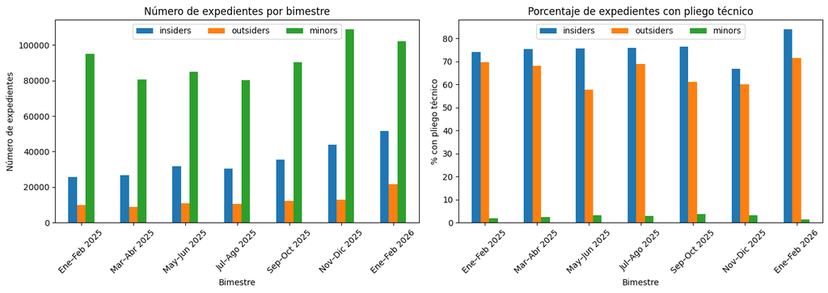

Una conclusión adicional de gran importancia para estimar la escalabilidad del sistema es que el número de pliegos técnicos y administrativos a descargar cada día se sitúa en el orden de unos 1000 documentos en total, lo cual puede suponer un problema de escalabilidad importante para el procesamiento de este volumen de documentos por el pipeline de procesamiento. Sin embargo, veremos más adelante que mediante un filtrado previo por CPV se puede disminuir considerablemente el número de pliegos a procesar a diario.

## 2.3. Cobertura de metadatos en los datasets de PLACE

Con el fin de evaluar la idoneidad de los datasets de PLACE para el cálculo de indicadores, se ha analizado la **cobertura de distintos metadatos relevantes**. La cobertura se define como el **porcentaje de expedientes que contienen información en el campo correspondiente**, calculado para cada bimestre del periodo comprendido entre **enero de 2025 y febrero de 2026**.

La siguiente figura presenta una subfigura para cada metadato analizado. En cada gráfico se muestra la evolución bimestral de la cobertura del campo correspondiente, expresada en porcentaje. Cada bimestre se representa mediante tres barras que corresponden a los tres datasets considerados (*insiders*, *outsiders* y *minors*).

En términos generales, los resultados muestran que **la gran mayoría de los metadatos analizados presentan una cobertura prácticamente completa**, cercana al 100 % en todos los datasets y periodos considerados. Este resultado no es sorprendente, ya que los campos seleccionados para su inclusión en los conjuntos de datos lo han sido precisamente por su relevancia y por su presencia en los tres conjuntos de datos utilizados en el sistema. Esta elevada cobertura resulta especialmente positiva desde el punto de vista del cálculo de indicadores, ya que garantiza que la mayor parte de los expedientes contiene la información necesaria para los análisis posteriores.

No obstante, se observan algunas **excepciones relevantes** que conviene destacar:

En conjunto, este análisis confirma que los datasets de PLACE presentan **una cobertura de metadatos elevada y suficientemente estable en el tiempo**, lo que refuerza su idoneidad como fuente de información para el cálculo de indicadores agregados en el sistema SIA. No obstante lo anterior, conviene que en el cálculo de indicadores se indique siempre el porcentaje de cobertura sobre el que dichos indicadores sean calculados.

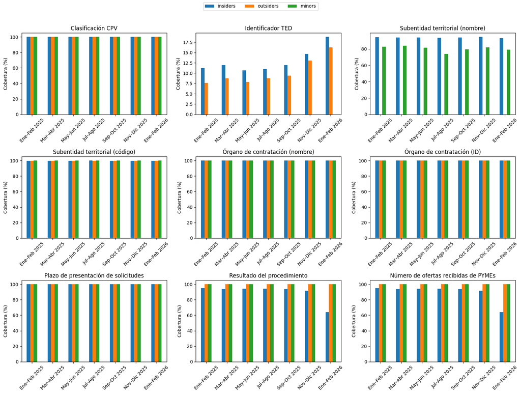

## 2.4. Distribución de los expedientes según CPV

En esta sección se analiza la distribución de expedientes en función de distintos **códigos CPV (Common Procurement Vocabulary)** que se consideran potencialmente relevantes para la identificación de procedimientos relacionados con Inteligencia Artificial. El objetivo de este análisis es evaluar el volumen relativo de expedientes asociados a cada uno de estos CPVs en los tres datasets considerados (*insiders*, *outsiders* y *minors*).

Las figuras mostradas anteriormente presentan, para cada dataset, el **número de expedientes asociados a cada uno de los CPVs seleccionados**. Un expediente se considera asociado a un determinado CPV cuando al menos uno de los códigos CPV presentes en el expediente coincide con el **prefijo de dos dígitos** del CPV analizado. De esta manera es posible agrupar expedientes que pertenecen a categorías amplias del vocabulario CPV, independientemente del nivel de detalle del código específico utilizado en la licitación.

Los CPVs seleccionados se han dividido en dos grupos. El primero (48, 72 y 73) incluye las **categorías potencialmente más relacionadas con tecnologías digitales e Inteligencia Artificial**, mientras que el segundo grupo recoge **categorías sectoriales o verticales** en las que la IA podría aparecer como componente tecnológico de soluciones más amplias.

| CPV | Categoría | Relevancia para IA | Descripción |
| --- | --- | --- | --- |
| 48 | Software y sistemas | Alta | Plataformas software, analítica de datos, visión por computador, NLP, MLOps, sistemas de información. |
| 72 | Servicios TI | Alta | Desarrollo de software a medida, integración de modelos, despliegue de sistemas, mantenimiento y data engineering. |
| 73 | Investigación y desarrollo | Alta | Proyectos de I+D, pilotos tecnológicos, desarrollo experimental y prototipos basados en IA o ML. |
| 33 | Equipos médicos, farmacéuticos y de precisión | Media | Equipos de diagnóstico por imagen, dispositivos médicos inteligentes y apoyo clínico basado en IA. |
| 38 | Equipos de laboratorio, ópticos y de precisión | Media | Instrumentación avanzada, sensores y sistemas de visión artificial. |
| 34 | Equipos de transporte | Media | Sistemas inteligentes de transporte, ADAS, optimización de flotas. |
| 35 | Seguridad, defensa y emergencias | Media | Analítica de vídeo, detección automática de anomalías, sistemas de apoyo a la decisión. |
| 71 | Arquitectura e ingeniería | Media | Simulación, optimización de diseño, gemelos digitales y modelos predictivos. |
| 79 | Servicios empresariales | Media | Automatización de procesos, analítica avanzada, soporte a decisiones. |
| 80 | Educación y formación | Media | Plataformas educativas adaptativas y sistemas de tutoría inteligente. |
| 90 | Medio ambiente y gestión de recursos | Media | Predicción de demanda, monitorización ambiental, clasificación automática de residuos o detección de fugas. |
| 30 | Equipos informáticos | Infraestructura | Hardware de computación utilizado en sistemas de IA. |
| 31 | Equipos eléctricos | Infraestructura | Infraestructura energética o electrónica asociada a sistemas inteligentes. |
| 32 | Equipos electrónicos | Infraestructura | Sensores, edge computing y dispositivos electrónicos avanzados. |
| 63 | Servicios auxiliares de transporte | Infraestructura | Servicios de datos y soporte a sistemas inteligentes de movilidad. |
| 64 | Telecomunicaciones | Infraestructura | Conectividad y servicios de transmisión de datos necesarios para sistemas basados en IA. |

Los resultados obtenidos muestran varios patrones relevantes:

- Dentro de los **CPVs considerados prioritarios**, los códigos **48 (software y sistemas)** y **72 (servicios TI)** presentan un volumen de expedientes claramente superior al del código **73 (investigación y desarrollo)** en los tres datasets analizados. Este resultado es coherente con la estructura habitual de la contratación pública en la que los proyectos estrictamente de I+D son relativamente menos frecuentes.
- En el caso de los CPVs secundarios o sectoriales, la distribución observada es **relativamente similar entre los datasets insiders y outsiders**, con una excepción notable: el código **33 (equipos médicos)** presenta una presencia significativamente mayor en el dataset *outsiders*. Este comportamiento resulta razonable si se tiene en cuenta que en el dataset *outsiders* el peso relativo de las **comunidades autónomas** es mayor que en *insiders*. Dado que las competencias en materia de **sanidad** están transferidas principalmente a las comunidades autónomas, es lógico observar un mayor volumen de expedientes asociados a equipamiento médico en este conjunto de datos.
- El dataset de **contratos menores (minors)** muestra algunas diferencias adicionales. En particular, el CPV **79 (servicios empresariales)** presenta una presencia relativamente mayor que en los otros datasets. No obstante, debe tenerse en cuenta que este tipo de contratos tendrá **una explotación más limitada dentro del sistema SIA**, ya que en la mayoría de los casos **no se dispone de acceso a los pliegos de licitación** asociados a estos procedimientos. Dado que buena parte del análisis semántico del sistema se basa precisamente en el contenido de los pliegos, la utilidad analítica de los contratos menores será necesariamente menor que la de los expedientes procedentes de *insiders* y *outsiders*.

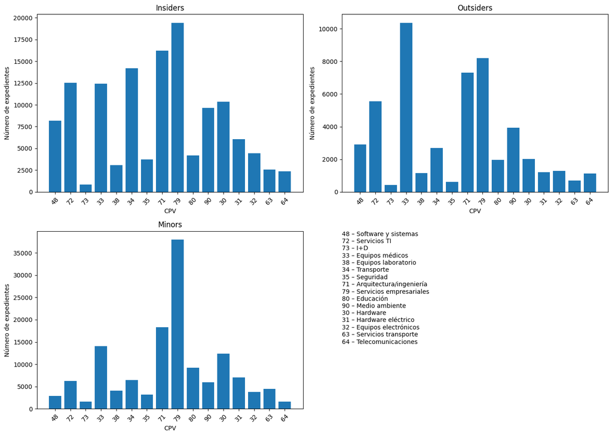

### 2.4.1. Volumen de expedientes asociados a los CPVs prioritarios

En esta sección se analiza el **número total de expedientes que contienen alguno de los CPVs preseleccionados** en el análisis anterior. Estos CPVs incluyen tanto las categorías consideradas **prioritarias para la detección de licitaciones relacionadas con Inteligencia Artificial** (48, 72 y 73) como otros CPVs sectoriales o de infraestructura donde también podrían aparecer soluciones basadas en IA.

El objetivo de este análisis es estimar el **volumen total de procedimientos que deberán ser evaluados por el detector de Inteligencia Artificial** que formará parte del sistema SIA. En el sistema final, el pipeline analizará inicialmente **todos los expedientes pertenecientes a estos CPVs**, y posteriormente aplicará un módulo de detección de IA que permitirá identificar cuáles de ellos están realmente relacionados con Inteligencia Artificial y deben incorporarse al portal web y al cálculo de indicadores.

La tabla siguiente muestra el número de expedientes asociados a los CPVs preseleccionados para cada bimestre del periodo analizado.

[output not shown]

Considerando únicamente los datasets **insiders** y **outsiders**, el número de expedientes candidatos a ser analizados oscila entre aproximadamente **16 800 y 36 600 expedientes por bimestre**. Aplicando la estimación de cobertura de pliegos (≈80 %), el número de documentos que el pipeline deberá procesar se sitúa aproximadamente entre **13 500 y 29 000 pliegos por bimestre**.

Si se distribuye este volumen de manera uniforme en el tiempo, esto corresponde aproximadamente a **entre 225 y 480 documentos diarios**, dependiendo del periodo considerado. En promedio, tomando el conjunto del intervalo analizado, el sistema deberá procesar **en torno a 350 documentos al día**.

### 2.4.2. Evolución bimestral de expedientes en los CPVs prioritarios (48, 72 y 73)

En el resto de este informe se utilizará la **agregación de los CPVs 48, 72 y 73** como aproximación para identificar expedientes potencialmente relacionados con Inteligencia Artificial. Estos tres códigos corresponden a las categorías de **software y sistemas (48)**, **servicios de tecnologías de la información (72)** e **investigación y desarrollo (73)**, que constituyen los ámbitos donde con mayor frecuencia aparecen licitaciones vinculadas con el desarrollo, despliegue o experimentación de soluciones basadas en IA.

Conviene señalar que esta aproximación se utiliza **únicamente con fines ilustrativos dentro de este informe**, cuyo objetivo principal es demostrar la **viabilidad técnica del cálculo de los distintos indicadores** que formarán parte del sistema. Por este motivo, **no se pretende que las cifras obtenidas representen una estimación precisa del número real de licitaciones relacionadas con Inteligencia Artificial** ya que 1) existen expedientes relacionados con IA en otros CPVs distintos de los considerados; 2) no todos los expedientes incluidos en los CPVs 48, 72 o 73 estarán necesariamente relacionados con IA.

En el sistema SIA final se implementará un enfoque más avanzado para abordar esta cuestión. En particular, el sistema permitirá **examinar todos los expedientes correspondientes a los CPVs seleccionados**, aplicando posteriormente un **módulo de detección automática de IA** basado en el análisis del contenido de los pliegos y de los metadatos de los procedimientos. Este detector será el encargado de identificar qué expedientes están efectivamente relacionados con Inteligencia Artificial, y serán estos los que finalmente se incorporen al portal web y se utilicen en el cálculo de los indicadores.

La siguiente figura muestra la **evolución bimestral del número de expedientes asociados a los CPVs 48, 72 y 73**, desglosada para los tres datasets considerados (*insiders*, *outsiders* y *minors*). En términos generales, el volumen de expedientes se mantiene relativamente estable durante la mayor parte del periodo analizado, aunque se observa un **incremento notable en los dos últimos bimestres del periodo**.

Este aumento resulta especialmente significativo en el dataset **insiders**, donde el número de expedientes prácticamente se duplica entre los primeros bimestres de 2025 y los últimos periodos analizados, alcanzando valores superiores a los 4.000 expedientes por bimestre. En el dataset **outsiders** también se observa un incremento, aunque de menor magnitud, con un aumento más moderado en el número de expedientes hacia finales del periodo. Por el contrario, en el dataset **minors** la evolución es mucho más estable, con variaciones relativamente pequeñas entre bimestres y sin una tendencia clara de crecimiento.

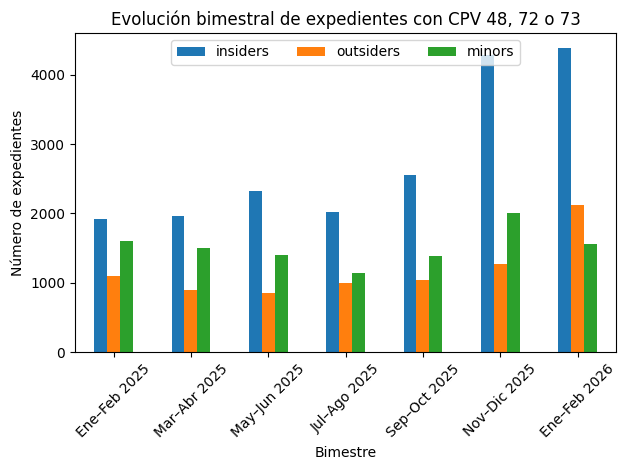

# 3. Indicadores

En esta sección se presentan distintos **indicadores cuantitativos aplicados a los datos de contratación pública**, con el objetivo de demostrar la **viabilidad de su cálculo a partir de los metadatos disponibles en los datasets de PLACE**. Muchos de los indicadores considerados están inspirados en los utilizados por la Comisión Europea en el **Single Market Scoreboard**, una herramienta de análisis que evalúa el funcionamiento de los mercados de contratación pública en los distintos Estados miembros de la Unión Europea a partir de indicadores relacionados con la competencia, la eficiencia administrativa y la calidad de los datos publicados.

El objetivo de este ejercicio no es tanto proporcionar estimaciones exhaustivas sobre la presencia de Inteligencia Artificial en la contratación pública, sino **mostrar que es posible calcular de forma sistemática distintos indicadores relevantes utilizando la información disponible en las plataformas de contratación pública**. Para ello, y siguiendo el enfoque descrito en secciones anteriores, los cálculos se realizan sobre un subconjunto de expedientes pertenecientes a **tres CPVs especialmente relevantes para el ámbito de la IA (48, 72 y 73)**. Este subconjunto permite ilustrar la metodología de cálculo sobre un volumen significativo de expedientes, manteniendo al mismo tiempo un ámbito temático razonablemente acotado. En el sistema final del SIA, la selección de expedientes relevantes se realizará mediante procedimientos más avanzados de identificación de actuaciones relacionadas con IA.

Para cada indicador se presentará, en primer lugar, una **definición formal del indicador**, incluyendo su descripción conceptual, el método de cálculo utilizado y los metadatos empleados para su estimación. A continuación, se mostrarán los **resultados agregados por periodos bimestrales**, así como las correspondientes visualizaciones gráficas.

Además de los valores del indicador, en todos los casos se incluye también el análisis de la **cobertura de los metadatos necesarios para su cálculo**. Este análisis resulta especialmente relevante, ya que permite evaluar no solo la magnitud de los indicadores, sino también la **calidad y completitud de la información disponible en las fuentes de datos**. De este modo, cada indicador sirve simultáneamente para ilustrar dos aspectos fundamentales: por un lado, el comportamiento observado en los procedimientos analizados y, por otro, la **viabilidad técnica de calcular dichos indicadores utilizando los metadatos estructurados disponibles en PLACE**.

El conjunto de indicadores analizados cubre diferentes dimensiones de la contratación pública, incluyendo aspectos relacionados con la **competencia en los procedimientos, la participación de empresas, la estructura de los contratos y la calidad de los datos publicados**. En conjunto, este ejercicio permite demostrar que los datos disponibles en las plataformas de contratación pública permiten construir un sistema de indicadores suficientemente rico como para apoyar análisis agregados y servicios avanzados de inteligencia sobre contratación pública.

## 3.1. Indicador 0: Volumen de contratación pública

| **Descripción** | Para cada elemento de agregación, y habiendo filtrado previamente según los criterios establecidos, se recuperarán todos los expedientes publicados y el presupuesto asociado a cada uno de ellos. |
| --- | --- |
| **Método de cálculo** | Suma del número de expedientes recuperados / Suma de los importes asociados a cada expediente. |
| **Metadatos relevantes** | **presupuesto_sin_iva** (presupuesto base de licitación sin impuestos) |

El primer indicador considerado en este informe corresponde al **volumen de contratación pública asociado a los CPVs prioritarios** identificados previamente (48 – Software y sistemas, 72 – Servicios TI y 73 – Investigación y desarrollo). Estos tres códigos se utilizan en esta fase del análisis como una aproximación inicial al conjunto de licitaciones potencialmente relacionadas con Inteligencia Artificial.

Los resultados obtenidos muestran que el **número de expedientes** se mantiene relativamente estable durante la mayor parte del periodo analizado, con valores aproximados de entre **1 900 y 2 500 expedientes por bimestre en el dataset insiders**, y entre **850 y 1 000 expedientes en outsiders** durante la mayor parte de 2025. En los últimos meses del periodo analizado se observa, sin embargo, un **incremento notable en el número de procedimientos**, especialmente en el dataset insiders, que supera los **4 000 expedientes por bimestre**, así como en outsiders, que también muestra un aumento significativo en el primer bimestre de 2026.

El análisis del **presupuesto estimado agregado** revela patrones aún más llamativos. Mientras que durante los primeros bimestres de 2025 el volumen económico agregado se sitúa aproximadamente entre **1,6 y 2,6 miles de millones de euros en insiders** y entre **0,7 y 1 miles de millones de euros en outsiders**, en los últimos meses del periodo analizado se observa un **incremento muy significativo del presupuesto total**. En particular, durante el bimestre **noviembre–diciembre de 2025** se alcanza un volumen agregado de aproximadamente **7,4 mil millones de euros en insiders** y **8,3 mil millones de euros en outsiders**, seguido de un nuevo incremento en el primer bimestre de 2026, donde insiders supera los **10 mil millones de euros**.

Este comportamiento sugiere la existencia de **uno o varios contratos de importe muy elevado** publicados durante esos periodos, especialmente en el dataset outsiders, donde el volumen económico agregado presenta variaciones muy pronunciadas entre bimestres.

Para interpretar correctamente estas cifras resulta útil considerar también el **importe medio por expediente**, que se obtiene dividiendo el presupuesto estimado agregado entre el número de procedimientos publicados. En los primeros bimestres del periodo analizado, el importe medio por expediente se sitúa aproximadamente en torno a **0,8–1,1 millones de euros en insiders** y **0,7–0,9 millones de euros en outsiders**, mientras que en el caso de los contratos menores el importe medio es mucho menor, situándose aproximadamente en torno a **5 000 euros por expediente**.

Más allá de los valores concretos del indicador y su análisis, estos resultados muestran que los datos disponibles permiten **calcular de forma directa y consistente tanto el número de expedientes como el volumen económico agregado asociado a los CPVs considerados**, así como derivar métricas adicionales como el importe medio por procedimiento. Por tanto, el análisis confirma la **viabilidad técnica del cálculo de este indicador utilizando la información disponible en los datasets de PLACE**, que es el objetivo principal de esta sección dentro del presente informe.

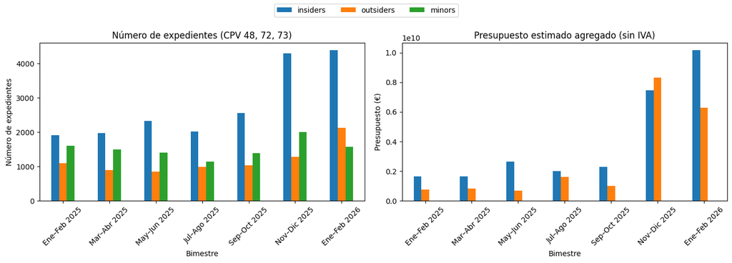

## 3.2. Indicador 1: Single bidder

[output not shown]

Este indicador mide la **proporción de lotes en los que únicamente se ha recibido una oferta**, lo que se conoce comúnmente como *single bidder*. Este indicador es utilizado con frecuencia en estudios de contratación pública para analizar el grado de competencia en los procedimientos de licitación. Valores elevados pueden indicar un menor nivel de competencia o un mercado reducido de proveedores para determinados tipos de contratos.

Para el cálculo del indicador se consideran **todos los lotes de los expedientes seleccionados**. Cuando un expediente no contiene lotes explícitos, se contabiliza como un único lote equivalente al expediente completo. De esta forma, cada expediente aporta uno o varios registros dependiendo de su estructura de lotes.

Las figuras que se muestran a continuación presentan dos elementos complementarios. En primer lugar, se muestra la **evolución bimestral del porcentaje de lotes con una única oferta**, desglosado para los tres datasets analizados (*insiders*, *outsiders* y *minors*). En segundo lugar, se presenta la **cobertura del campo `ofertas_recibidas`**, es decir, el porcentaje de lotes para los que se dispone de información sobre el número de ofertas recibidas.

En términos generales, la **cobertura de la información es muy elevada**, situándose en la mayoría de los bimestres entre aproximadamente el **94 % y el 97 % en los datasets insiders y outsiders**, y prácticamente en el **100 % en el caso de minors**. La única excepción relevante se observa en el último bimestre del periodo analizado en el dataset insiders, donde la cobertura disminuye hasta alrededor del **70 %**, probablemente debido a retrasos en la actualización de la información en los procedimientos más recientes.

En cuanto a los valores del indicador, se observa que el **porcentaje de lotes con una única oferta es relativamente estable a lo largo del tiempo**. En los datasets insiders y outsiders los valores se sitúan generalmente entre **40 % y 55 %**, con variaciones moderadas entre bimestres. Por su parte, el dataset de **contratos menores (minors)** presenta valores significativamente más elevados, situándose en torno al **77–84 %** de los lotes con una única oferta. Este resultado es coherente con la naturaleza de los contratos menores, que suelen corresponder a procedimientos de menor importe y en muchos casos se adjudican tras solicitar oferta a un número reducido de proveedores.

En conjunto, los resultados muestran que tanto la **cobertura de los metadatos necesarios como la estabilidad temporal del indicador** permiten calcular de forma consistente el porcentaje de procedimientos con una única oferta. Por tanto, el análisis confirma la **viabilidad del cálculo de este indicador utilizando la información disponible en los datasets de PLACE**.

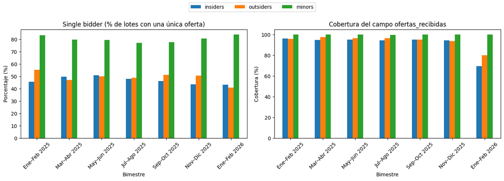

## 3.3. Indicador 2: Direct awards

[output not shown]

Este indicador refleja la **proporción de contratos adjudicados sin una convocatoria abierta de ofertas**, lo que permite evaluar indirectamente el nivel de **transparencia y competencia** en los procesos de contratación pública. En general, los procedimientos con convocatoria abierta (por ejemplo, procedimientos abiertos o restringidos) tienden a fomentar una mayor concurrencia de licitadores y, por tanto, a mejorar la eficiencia del gasto público. Por el contrario, los procedimientos negociados sin publicidad suelen implicar una menor competencia potencial.

Las figuras calculadas muestran, por un lado, la **evolución bimestral del porcentaje de procedimientos adjudicados mediante negociación sin publicidad** y, por otro, la **cobertura del campo `tipo_procedimiento`** en los datasets analizados.

En primer lugar, cabe destacar que la **cobertura del metadato es prácticamente completa**, situándose en torno al **100 % en todos los bimestres y datasets analizados**. Esto indica que la información necesaria para calcular el indicador está disponible de forma sistemática en los datos de PLACE, lo que permite calcular este indicador de forma consistente.

En cuanto a los valores del indicador, se observa que el **porcentaje de procedimientos negociados sin publicidad se sitúa generalmente entre aproximadamente el 12 % y el 22 %** en los datasets *insiders* y *outsiders*. En el caso de *insiders*, se aprecia una **ligera tendencia descendente a lo largo del periodo analizado**, pasando de valores cercanos al 22 % en los primeros bimestres de 2025 a aproximadamente el 13 % en el primer bimestre de 2026. En *outsiders*, los valores son algo más elevados en algunos bimestres, aunque se mantienen dentro de un rango relativamente similar.

En conjunto, los resultados muestran que tanto la **disponibilidad de los metadatos necesarios como la estabilidad temporal de los valores del indicador** permiten calcular de forma fiable la proporción de procedimientos adjudicados mediante negociación sin publicidad. Por tanto, el análisis confirma nuevamente la **viabilidad del cálculo de este indicador a partir de la información disponible en los datasets de PLACE**, que constituye el objetivo principal de esta fase del estudio.

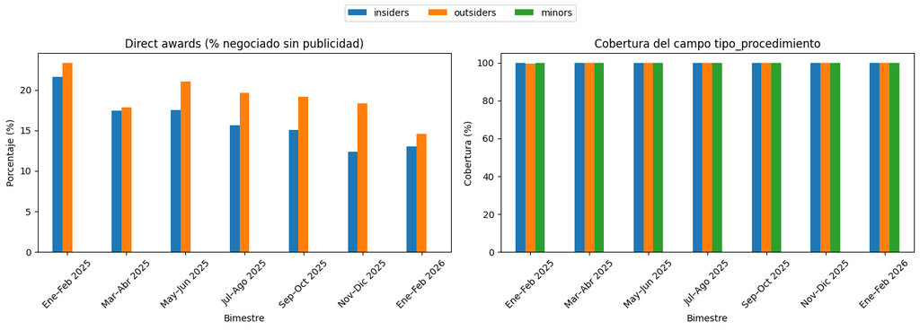

## 3.4. Indicador 3: Procedimientos publicados en TED

[output not shown]

Las figuras muestran la **evolución bimestral del porcentaje de expedientes publicados en TED** para los tres datasets analizados (*insiders*, *outsiders* y *minors*), considerando únicamente los expedientes pertenecientes a los CPVs prioritarios (48, 72 y 73).

Los resultados muestran que el **porcentaje de procedimientos publicados en TED aumenta progresivamente a lo largo del periodo analizado**. En el dataset *insiders*, el indicador pasa de aproximadamente **18 % en los primeros bimestres de 2025 a valores cercanos al 28 % en los últimos periodos analizados**. En el caso de *outsiders*, los valores son inicialmente más bajos, situándose en torno al **9–12 %**, aunque también muestran una tendencia creciente que alcanza aproximadamente el **21 % en el primer bimestre de 2026**.

Por su parte, el dataset **minors** presenta un valor del indicador igual a **0 % en todos los periodos**, lo cual es coherente con la naturaleza de los **contratos menores**, que se sitúan muy por debajo de los umbrales económicos que obligan a publicar las licitaciones en el portal TED.

En conjunto, los resultados muestran que una **fracción relevante de los procedimientos asociados a los CPVs analizados se publica en TED**, lo que indica que una parte significativa de estos contratos corresponde a procedimientos de mayor tamaño económico y potencialmente abiertos a la competencia internacional. Asimismo, la disponibilidad del identificador TED en los metadatos permite calcular este indicador de forma directa, lo que confirma nuevamente la **viabilidad de su cálculo utilizando la información disponible en los datasets de PLACE**.

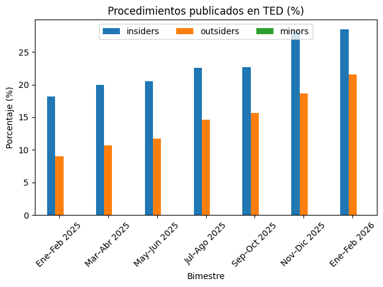

## 3.5. Indicador 6: Decision speed

[output not shown]

Las figuras muestran la evolución bimestral del tiempo medio de decisión en los procedimientos analizados, así como la cobertura de los metadatos necesarios para su cálculo. En este caso, el indicador se ha calculado **únicamente para el dataset *insiders***, ya que el dataset *outsiders* no incluye de forma sistemática la fecha de adjudicación (`fecha_acuerdo`), lo que impide calcular el intervalo temporal necesario para este indicador. Asimismo, el análisis se restringe a **procedimientos de tipo "Abierto"**, con el objetivo de garantizar la comparabilidad entre procedimientos y alinearse con la definición utilizada habitualmente en indicadores de eficiencia de contratación pública.

Los resultados muestran que el **tiempo medio de decisión se sitúa de forma bastante estable entre aproximadamente 63 y 70 días** a lo largo del periodo analizado. No se observa una tendencia temporal clara, aunque sí pequeñas variaciones entre bimestres que reflejan la variabilidad normal en la duración de los procesos de evaluación de ofertas. La cobertura del indicador es del **100 % en todos los bimestres analizados**, lo que indica que los metadatos necesarios para calcular este indicador están disponibles de forma sistemática en el dataset considerado.

En conjunto, este análisis confirma que es **posible calcular de forma fiable el indicador de velocidad de decisión utilizando los metadatos disponibles en los datos de PLACE**, al menos para los procedimientos abiertos incluidos en el dataset *insiders*. Esto demuestra nuevamente la **viabilidad del cálculo de indicadores de eficiencia administrativa a partir de los metadatos estructurados disponibles en las plataformas de contratación pública**.

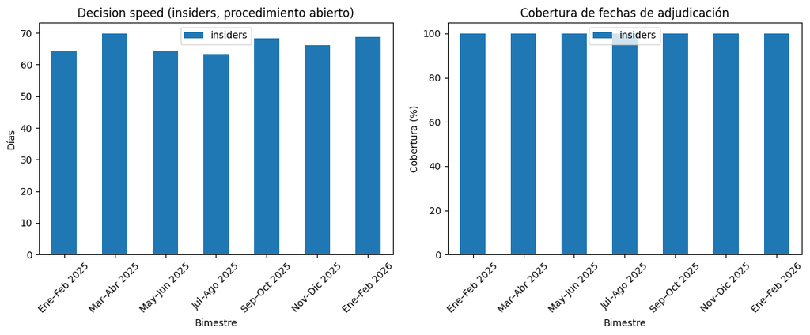

## 3.6. Indicador 7: Participación de PYMEs

[output not shown]

La **cobertura del metadato `ofertas_pymes` es muy alta**, situándose de forma sistemática en valores cercanos al **97–98 %**, lo que indica que la información necesaria para calcular el indicador está disponible en la gran mayoría de los procedimientos considerados.

En conjunto, este análisis confirma que los metadatos disponibles en los datos de PLACE permiten **calcular de forma fiable indicadores relacionados con la participación de PYMEs en los procedimientos de contratación pública**, al menos para el dataset *insiders*. Esto refuerza nuevamente la **viabilidad del cálculo de indicadores de competencia y acceso al mercado utilizando información estructurada procedente de las plataformas de contratación pública**.

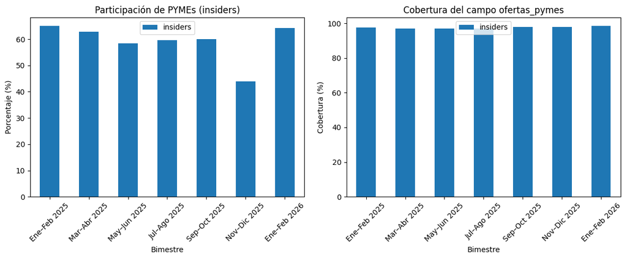

## 3.7. Indicador 8: Proporción de ofertas presentadas por PYMEs

[output not shown]

Los resultados muestran que **aproximadamente entre el 50 % y el 59 % de las ofertas recibidas proceden de PYMEs** a lo largo del periodo analizado. Este valor se mantiene relativamente estable entre bimestres, con pequeñas fluctuaciones que reflejan variaciones normales en la composición de las licitaciones. En términos generales, los resultados indican que **una parte muy significativa de las ofertas presentadas en los procedimientos analizados corresponde a empresas de tamaño pequeño o mediano**, lo que sugiere un nivel relativamente alto de participación de este tipo de empresas en el mercado de contratación pública asociado a los CPVs analizados.

La **cobertura del indicador es muy elevada**, situándose sistemáticamente en valores próximos al **97–98 %**, lo que indica que la información necesaria para calcularlo está disponible en prácticamente todos los procedimientos considerados.

En conjunto, este análisis confirma que los metadatos disponibles en los datos de PLACE permiten **analizar no solo la presencia de PYMEs en los procedimientos de contratación, sino también su peso relativo en el conjunto de ofertas presentadas**, lo que refuerza la viabilidad del cálculo de indicadores relacionados con la accesibilidad del mercado de contratación pública para este tipo de empresas.

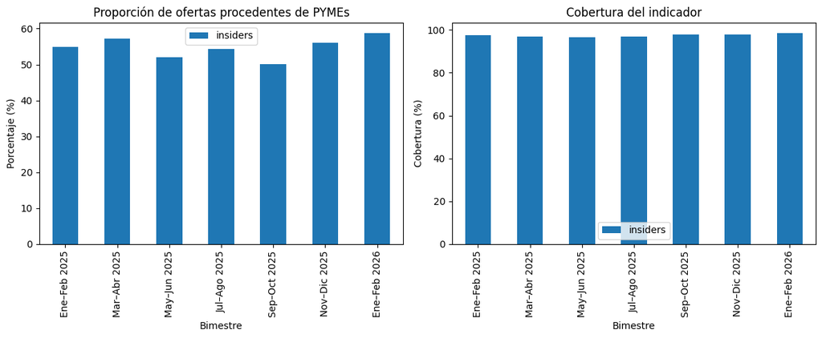

## 3.8. Indicador 9: Procedimientos divididos en lotes

[output not shown]

Las figuras muestran la **evolución bimestral del porcentaje de procedimientos divididos en lotes** para los tres datasets analizados (*insiders*, *outsiders* y *minors*), así como la cobertura del metadato utilizado para su cálculo.

En primer lugar, cabe destacar que la **cobertura del campo `lotes` es completa en todos los datasets y periodos**, lo que permite calcular el indicador de forma consistente en todas las fuentes de datos consideradas.

En cuanto a los resultados, se observa que la **proporción de procedimientos divididos en lotes se sitúa generalmente entre el 6 % y el 11 %** en los datasets *insiders* y *outsiders*. Los valores son relativamente estables a lo largo del periodo analizado, aunque se aprecia un ligero aumento en el primer bimestre de 2026, donde el indicador alcanza valores cercanos al **11–12 %**. En el caso de *outsiders*, los valores son en general ligeramente superiores a los observados en *insiders*, aunque ambos datasets presentan magnitudes comparables.

Por el contrario, en el dataset **minors** la proporción de procedimientos con múltiples lotes es prácticamente nula, con valores cercanos a **0 % en todos los bimestres**. Este resultado es coherente con la naturaleza de los **contratos menores**, que suelen corresponder a adquisiciones de menor tamaño y complejidad, donde la división en lotes resulta poco frecuente.

En conjunto, los resultados muestran que la división de procedimientos en lotes **no es una práctica mayoritaria en los expedientes analizados**, aunque sí está presente en una fracción significativa de los procedimientos en los datasets principales (*insiders* y *outsiders*). Asimismo, el análisis confirma que la estructura de datos disponible permite **identificar de forma directa los procedimientos divididos en lotes**, lo que demuestra nuevamente la viabilidad de calcular indicadores estructurales del diseño de los procedimientos de contratación pública a partir de los metadatos disponibles en PLACE.

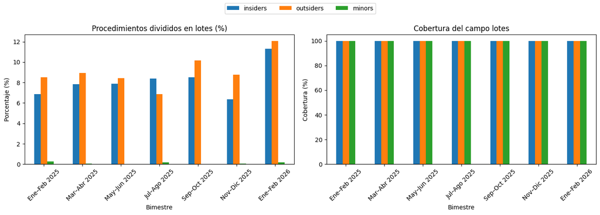

## 3.9. Indicador 11: Contratos sin identificador del adjudicatario

[output not shown]

Las figuras muestran la evolución bimestral del **porcentaje de contratos adjudicados sin identificador del adjudicatario** para los tres datasets analizados (*insiders*, *outsiders* y *minors*), así como la cobertura del metadato utilizado para su cálculo.

En primer lugar, se observa que la **cobertura del campo identificador es completa en todos los datasets**, lo que permite calcular el indicador de forma consistente en todos los periodos analizados.

En cuanto a los resultados, el porcentaje de contratos sin identificador del adjudicatario se mantiene **relativamente bajo en todos los datasets**, situándose generalmente entre aproximadamente **5 % y 8 % en *insiders*** y entre **4 % y 6 % en *outsiders***. Estos valores muestran una ligera variabilidad entre bimestres, pero en general se mantienen dentro de rangos similares a lo largo del periodo analizado.

En el caso del dataset **minors**, los valores son significativamente más bajos, situándose en torno al **1 % o menos en todos los periodos**.

En conjunto, los resultados muestran que **la gran mayoría de los contratos adjudicados incluyen un identificador del adjudicatario**, lo que permite identificar de forma fiable a las empresas participantes en los procedimientos de contratación pública. Asimismo, el análisis confirma que los metadatos disponibles en los datasets de PLACE permiten **evaluar indicadores de calidad del dato relacionados con la identificación de los adjudicatarios**.

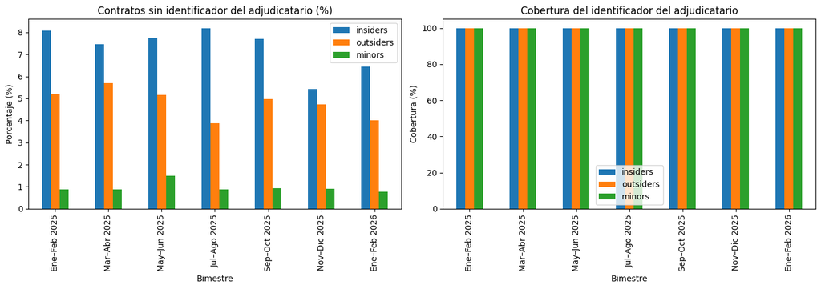

## 3.10. Indicador 12: Procedimientos sin identificador del comprador

[output not shown]

Las figuras muestran la evolución bimestral del **porcentaje de procedimientos sin identificador del comprador** para los tres datasets analizados (*insiders*, *outsiders* y *minors*), así como la cobertura del metadato utilizado para su cálculo.

Los resultados muestran que el **identificador del órgano de contratación está prácticamente siempre presente en los datos**, con valores del indicador iguales a **0 % en todos los periodos para los datasets *insiders* y *minors***. En el caso de *outsiders* se observan únicamente valores residuales en algunos bimestres, siempre por debajo del **0,2 % de los procedimientos**.

La cobertura del metadato es **completa en todos los datasets y periodos**, lo que indica que la información necesaria para calcular el indicador está disponible en todos los registros analizados.

En conjunto, los resultados muestran que la **identificación de las entidades compradoras está bien documentada en los datos de contratación analizados**, lo que permite realizar análisis fiables sobre qué organismos públicos participan en los distintos procedimientos de contratación. Asimismo, el análisis confirma la **viabilidad de calcular indicadores de calidad del dato relacionados con la identificación de los compradores a partir de los metadatos disponibles en PLACE**.

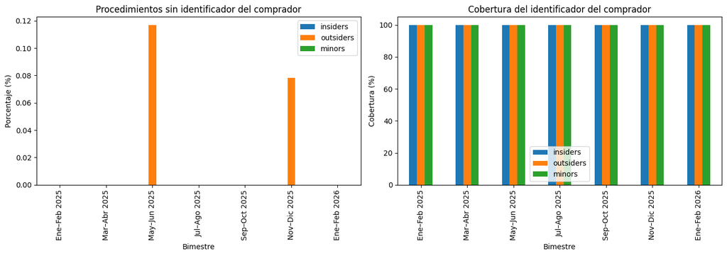

# 4. Filtros disponibles para el cálculo de indicadores

Los indicadores presentados en la sección anterior se han calculado aplicando un conjunto reducido de criterios de selección sobre los datos disponibles. En particular, los análisis realizados en este documento se han centrado en los expedientes asociados a los **CPVs 48, 72 y 73**, con el objetivo de ilustrar la **viabilidad técnica del cálculo de indicadores sobre subconjuntos específicos de la contratación pública**.

En el sistema SIA final, los endpoints responsables del cálculo de indicadores permitirán aplicar **distintos filtros sobre los expedientes antes de realizar las agregaciones**, de manera análoga al filtrado aplicado en este informe. Estos filtros permitirán construir consultas flexibles sobre los datos de contratación pública, facilitando el análisis de distintos segmentos del mercado de contratación.

A continuación se describen los **principales criterios de filtrado que podrán incorporarse a los endpoints del sistema**. Estos filtros podrán utilizarse de forma independiente o combinada.

## 4.1. Selección de fuente de datos

El sistema permitirá seleccionar la **fuente o fuentes de datos** sobre las que se desea realizar el análisis:

- **insiders**: licitaciones publicadas en los perfiles del contratante de la Plataforma de Contratación del Sector Público.
- **outsiders**: licitaciones agregadas procedentes de plataformas autonómicas u otras fuentes externas.
- **minors**: contratos menores publicados en los perfiles del contratante.

## 4.2. Rango temporal

Para el filtrado temporal se puede utilizar cualquiera de los dos metadatos siguientes:

- **updated**: fecha de última actualización del expediente en la plataforma.
- **plazo_presentacion**: fecha límite de presentación de ofertas.

Este filtro permitirá calcular indicadores sobre cualquier intervalo temporal definido por el usuario.

## 4.3. Rango de importe de licitación

El sistema permitirá restringir el análisis a procedimientos cuya **cuantía económica se encuentre dentro de un rango determinado**.

Este filtro se aplicará utilizando el metadato:

- **presupuesto_sin_iva**: presupuesto base de licitación sin impuestos.

## 4.4. Clasificación CPV

Uno de los filtros principales será la **clasificación CPV (Common Procurement Vocabulary)**, que permite restringir el análisis a determinados sectores de actividad.

El filtrado se realizará utilizando el campo:

- **cpv_list**: lista de códigos CPV asociados al expediente.

Este filtro permite seleccionar desde **niveles agregados del CPV (por ejemplo los dos primeros dígitos)** hasta clasificaciones más específicas. En el presente documento, por ejemplo, se ha utilizado este criterio para seleccionar los CPVs **48, 72 y 73**, relacionados con software, servicios TI e I+D.

## 4.5. Ubicación geográfica

El sistema permitirá filtrar los procedimientos en función de su **localización geográfica**. En función del nivel de detalle disponible en los metadatos, se podrán aplicar filtros basados en:

- **subentidad_nacional**: nombre de la región o comunidad autónoma asociada al procedimiento.
- **codigo_subentidad_territorial**: código territorial normalizado asociado a la ubicación del contrato.

Este filtro permitirá analizar los indicadores por **ámbito territorial**, facilitando la comparación entre distintas regiones o comunidades autónomas.

## 4.6. Entidad adjudicadora

El sistema permitirá restringir el análisis a procedimientos publicados por una **entidad adjudicadora concreta**.

Los metadatos relevantes para este filtrado son:

- **organo_id**: identificador del órgano de contratación.
- **organo_nombre**: nombre del órgano de contratación.

El filtrado se realizará generalmente utilizando el **identificador del órgano de contratación**, mientras que el nombre de la entidad se utilizará para mostrar la información al usuario.

## 4.8. Clasificación temática mediante modelado de tópicos

Además de los metadatos administrativos disponibles en las fuentes de datos, el sistema SIA incorporará **información adicional generada automáticamente mediante técnicas de Inteligencia Artificial**.

En particular, el módulo de modelado de tópicos descrito en entregables anteriores permitirá **asignar a cada expediente una distribución de probabilidades sobre distintos tópicos temáticos**. Cada expediente podrá estar asociado a varios tópicos con distintos pesos.

Esta información permitirá introducir un nuevo criterio de filtrado:

- selección de expedientes en los que un determinado tópico supere un **umbral mínimo de relevancia**,

Este mecanismo permitirá complementar los filtros tradicionales basados en CPV con una **clasificación temática basada en el contenido real de los documentos**, lo que resulta especialmente útil en ámbitos tecnológicos como la Inteligencia Artificial.

En conjunto, estos mecanismos de filtrado permitirán que los endpoints del SIA realicen el cálculo de indicadores sobre **subconjuntos altamente configurables de los datos de contratación pública**, proporcionando una base flexible para el análisis agregado de los procedimientos y la generación de servicios de inteligencia sobre contratación pública.